# Berkeley Interpersonal Contact Study - Wave 1 - Spring 2020

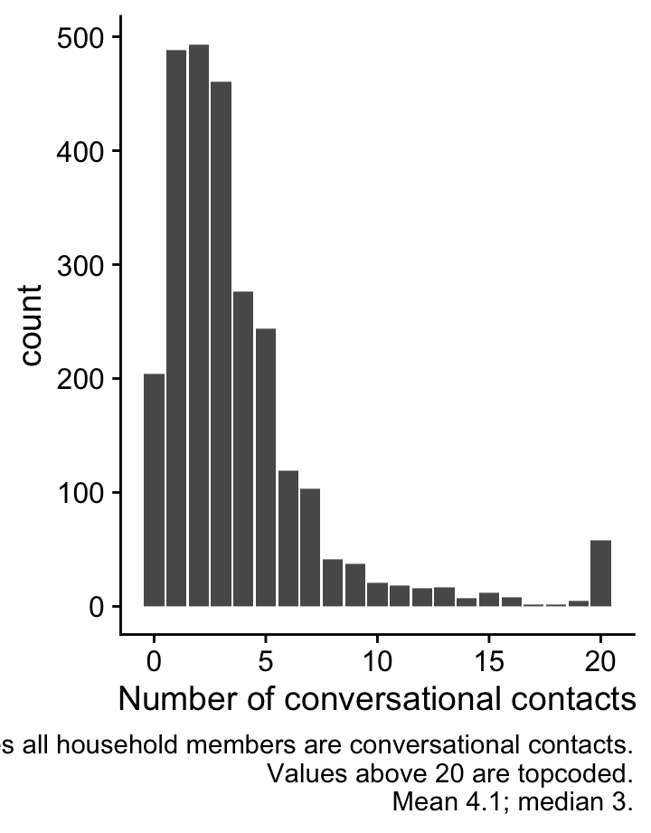

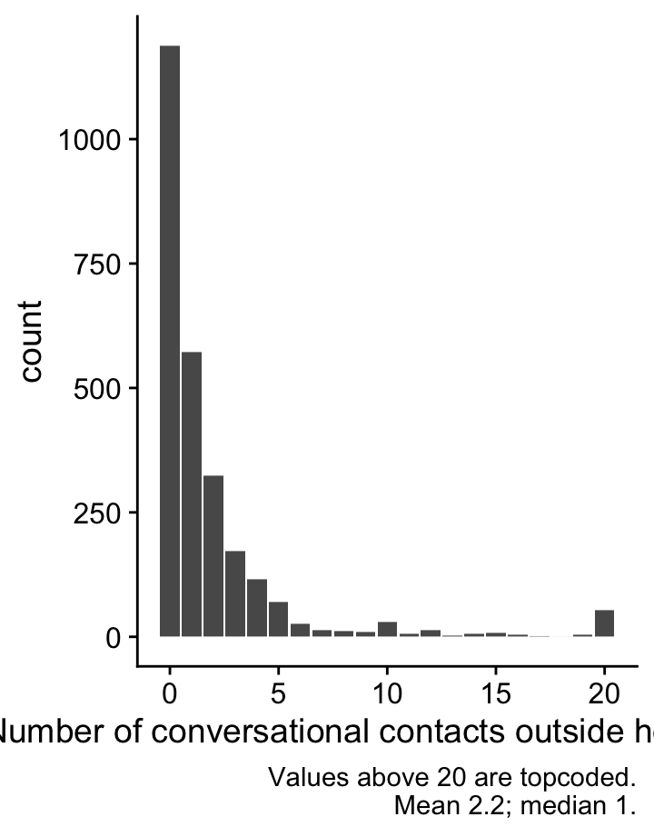

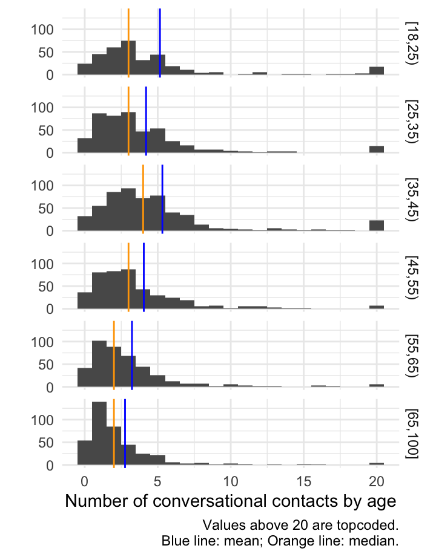

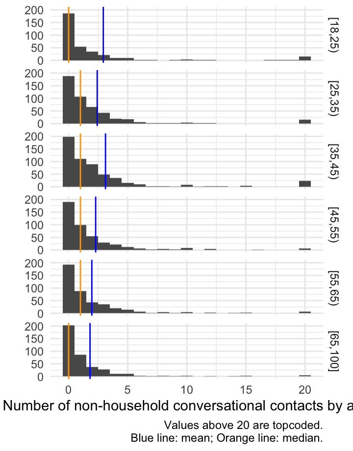

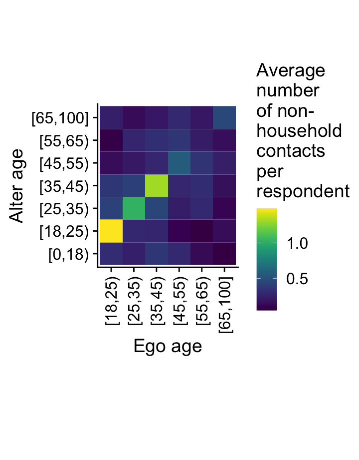

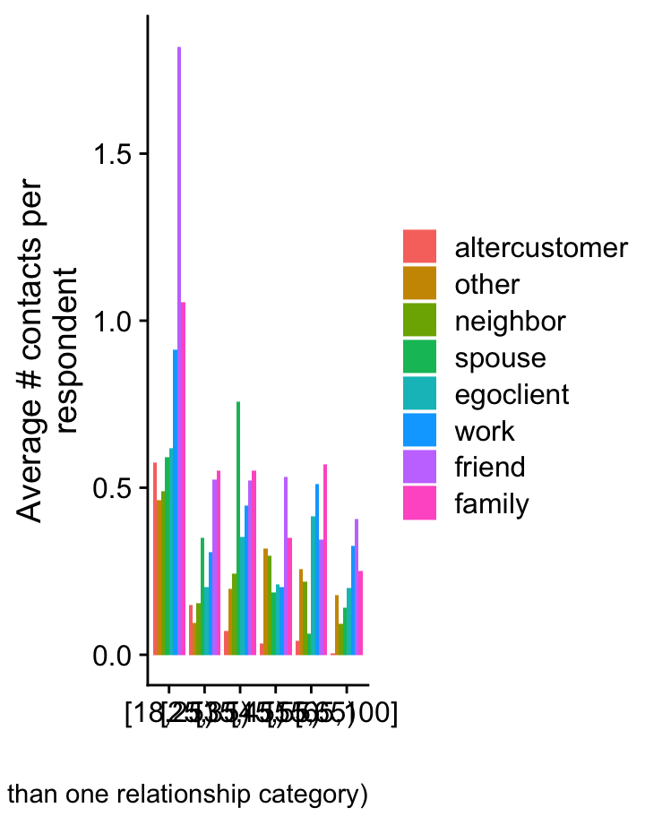

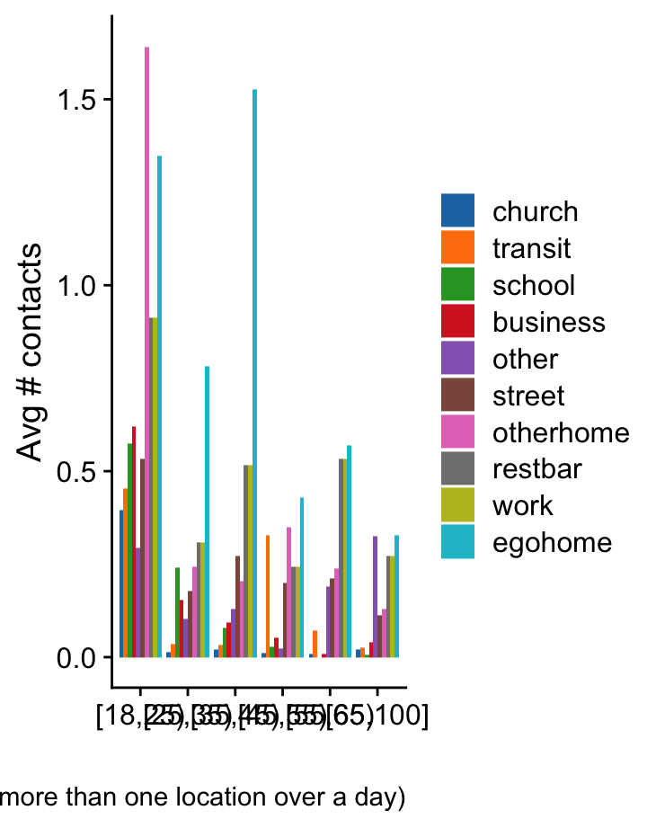

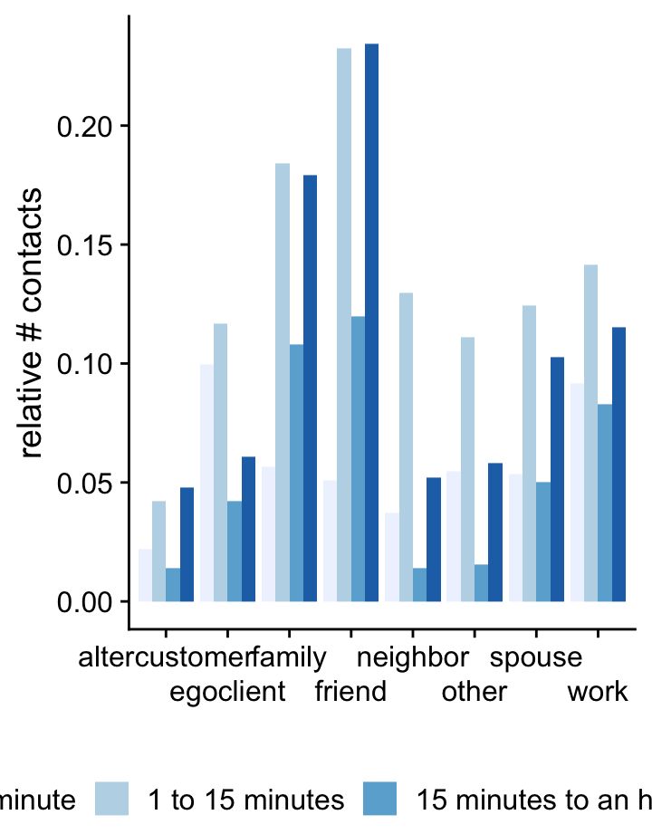

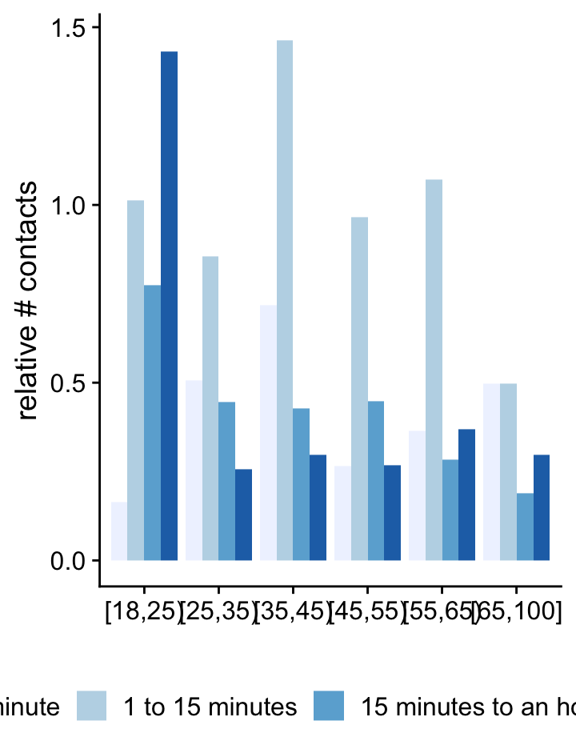

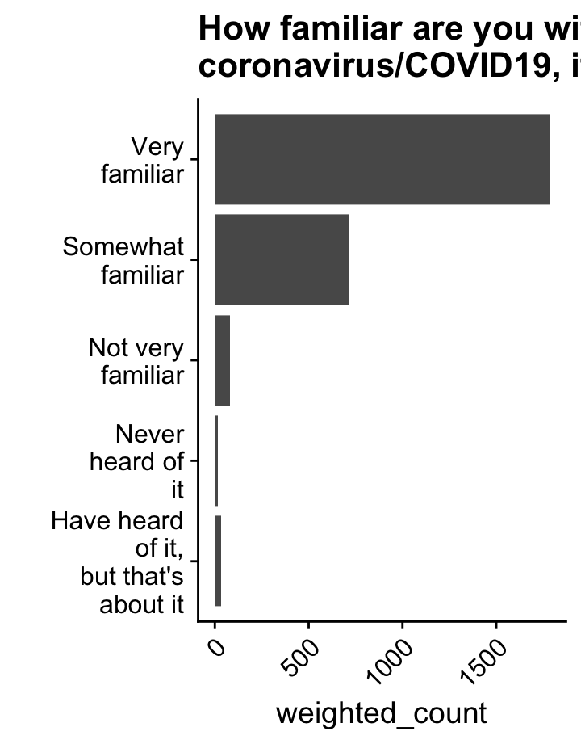

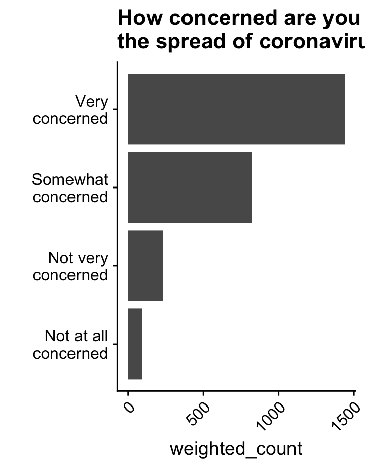

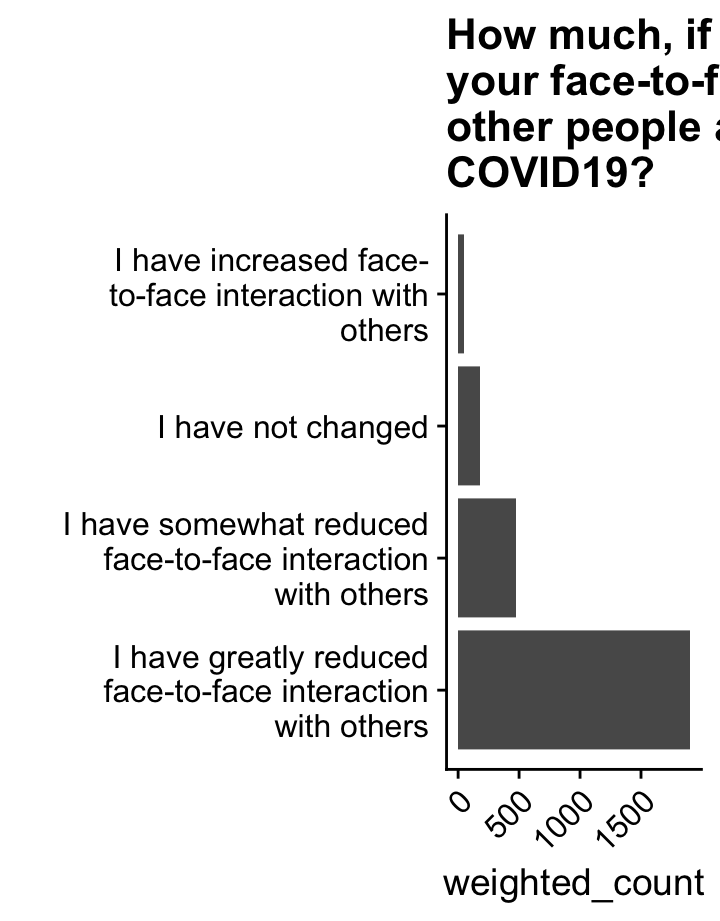

[4 more figures not shown]

### About

This dashboard shows results from Wave 1 of the Berkeley Interpersonal Contact Study (BICS) in Spring 2020.

Caveats / underway:

- the estimates have been weighted to improve sample representativeness. Weights are based on age, sex, race/ethnicity, household size, and urbanicity
- see the ‘Contact definition’ tab for some important notes on how we define contacts
- these results are from Wave 1; the dashboard previously showed results from the pilot Wave 0 (the previous dashboard is here
- a comparison to Wave 0 results is coming soon; the instrument changed in some ways, and so a careful comparison will take some time

If you have questions or are interested in funding this study, please contact us at bics@demog.berkeley.edu.

This project has been approved by the UC Berkeley IRB (Protocols 2020-03-13128 and 2020-04-13215). Initial support provided by a Berkeley Population Center pilot grant (NICHD P2CHD073964).

### Updates

**Wave 1 results updated 2020-05-20**

2020-05-20:

- Updated mixing matrix to add symmetrization

2020-05-07:

- Updated dashboard to show most recent results from Wave 1. The first set of results, Wave 0, can be found in the previous dashboard

2020-04-20:

- Most plots are now weighted to improve sample representativeness using raking. (These weights have made little difference to the previous estimates)

2020-04-17:

- Read a short [write-up of the Wave 0 results](https://medrxiv.org/cgi/content/short/2020.04.13.20064014v1) (this dashboard focuses on more recent results)

### Number of conversational contacts

#### Number of conversational contacts

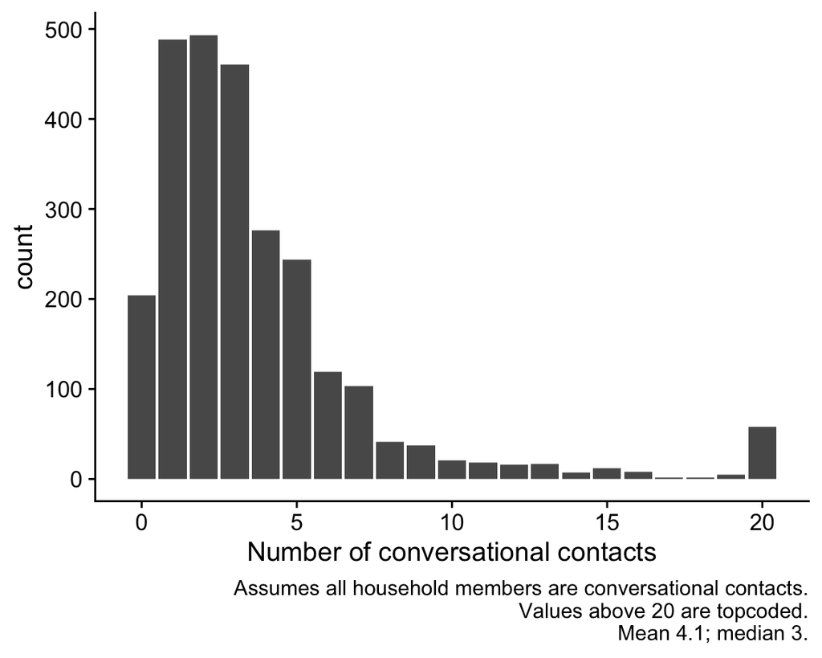

#### Number of conversational contacts outside the household

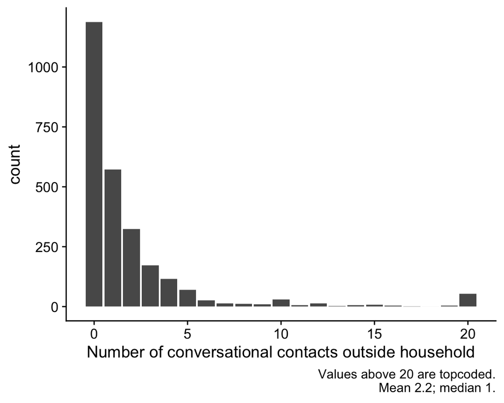

#### Conversational contacts by age

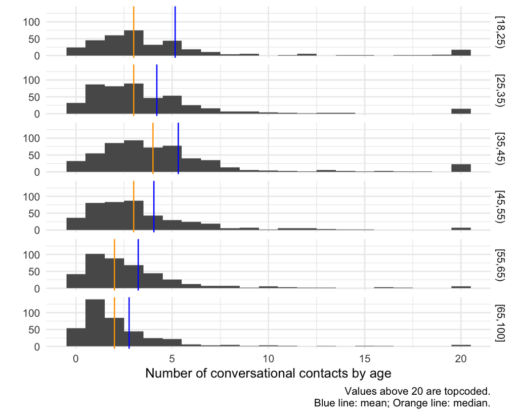

#### Conversational contacts outside household by age

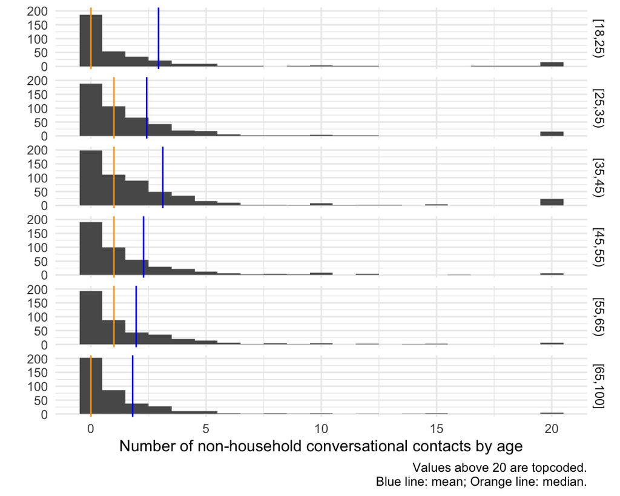

### Mixing

**NB: please see the ‘data’ tab if you want the numbers behind these mixing estimates**

#### By age/sex - non hh contacts

The matrix calculated below uses the symmetrization formula found in the vignette for the [socialmixr](https://cran.r-project.org/web/packages/socialmixr/vignettes/introduction.html) package.  
(We calculate it by hand, since the package was not designed for data collected using our instrument.) We used the 2018 American Community Survey to obtain the national age-distribution.

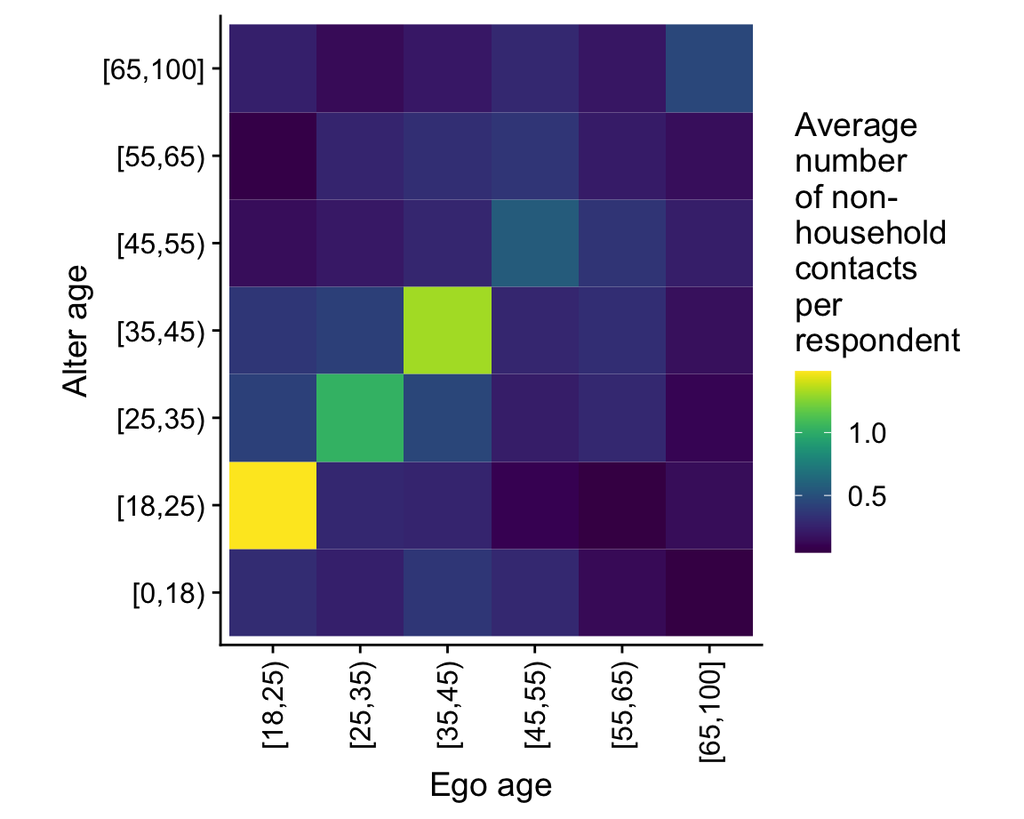

#### Relationships - non-hh contacts

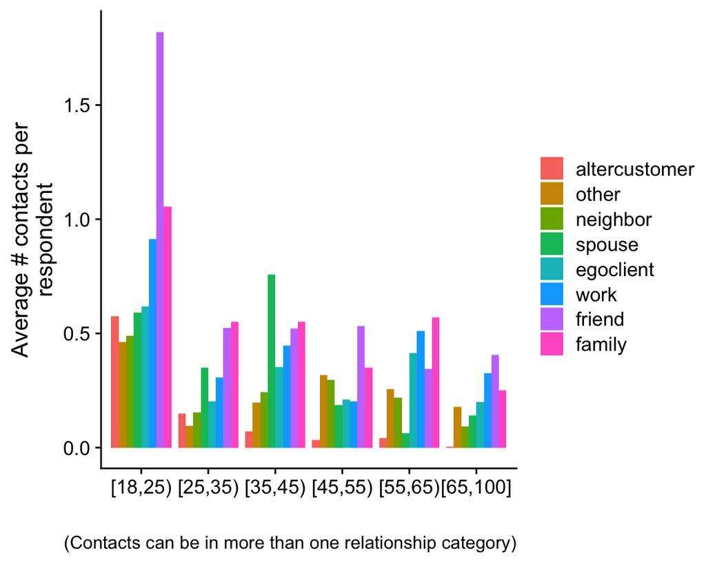

#### Locations - non-hh contacts

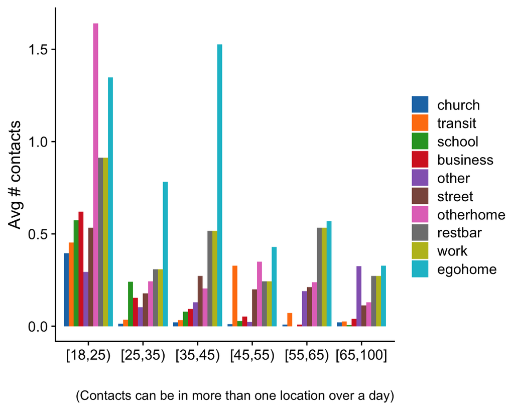

#### Contact durations - by relationship, non-hh contacts

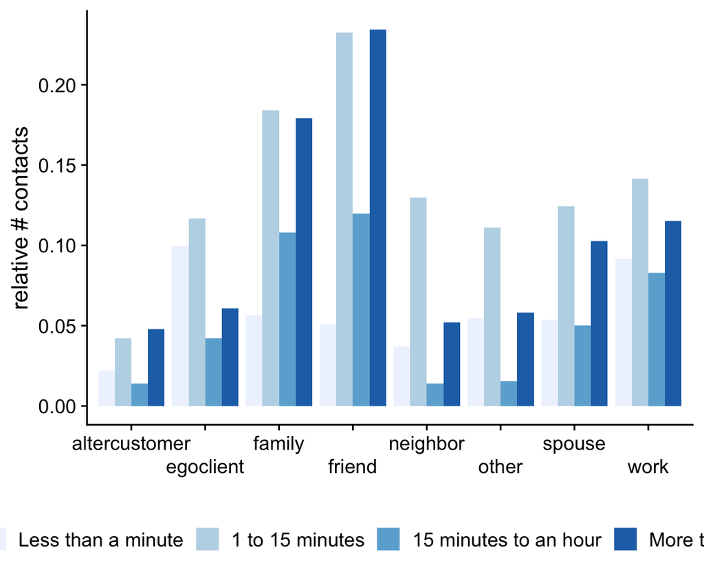

#### Contact durations - by respondent age, non-hh contacts

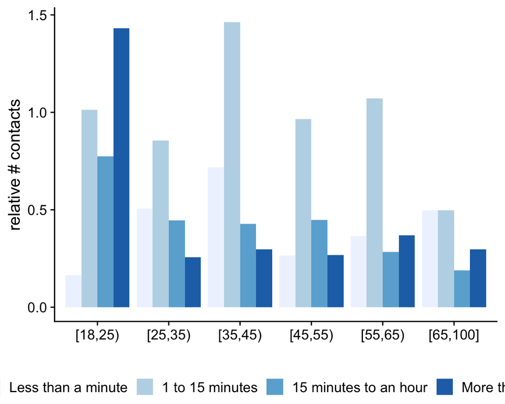

### COVID-19

#### Awareness

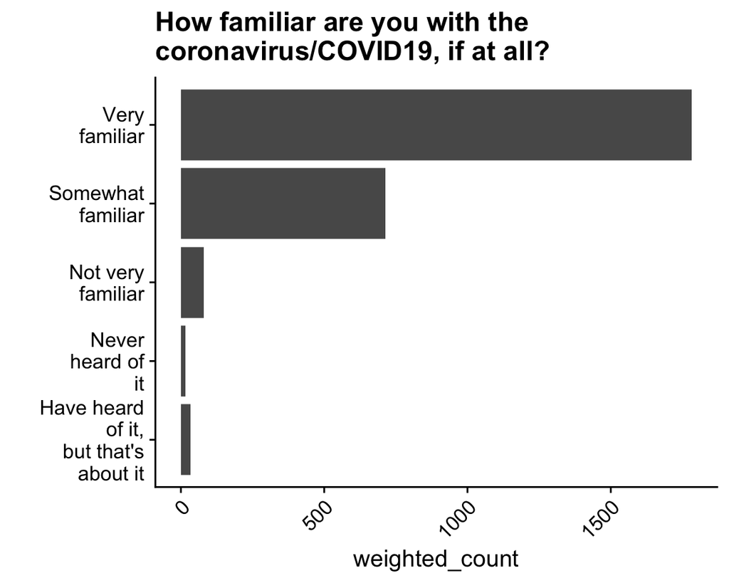

#### Concern

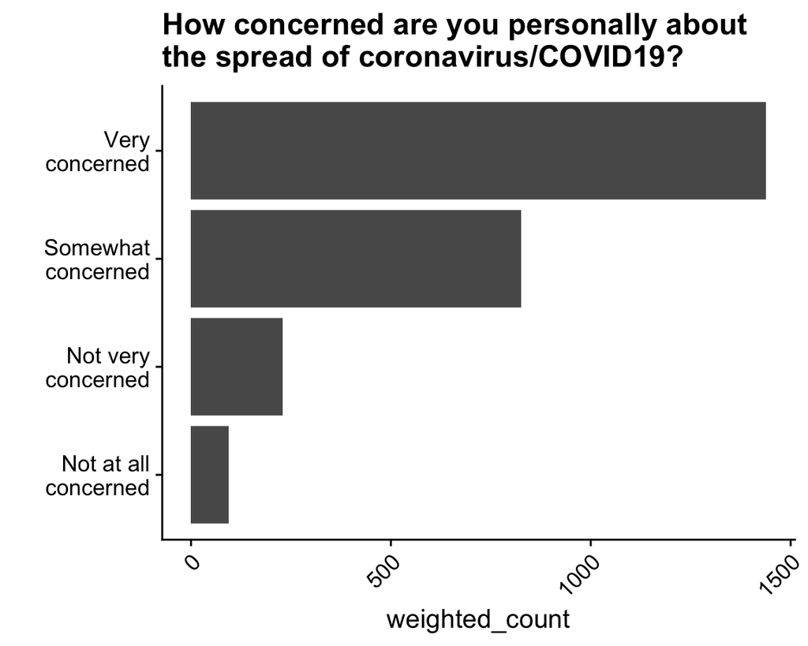

#### Behavior change

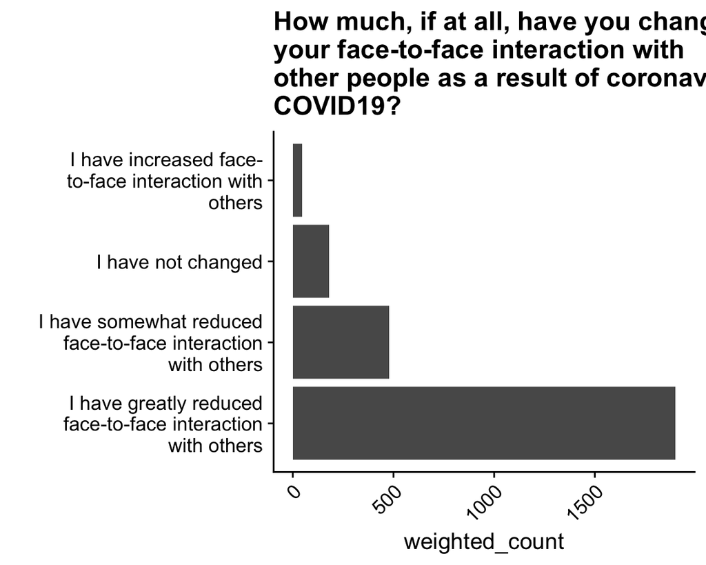

### Respondent characteristics

#### Weights

The pooled estimates have been weighted using raking to improve sample representativeness. Weights are based on

- Age
- Sex
- Age/sex interaction
- Race (Black, White, Other)
- Hispanic status
- Household size (1/2/3/4/5+)
- Urbanicity

Population values are taken from the 2018 ACS, estimated from an [IPUMS USA](https://usa.ipums.org/usa/index.shtml) extract. We used the R packages [ipumsr](https://cran.r-project.org/web/packages/ipumsr/vignettes/ipums.html), leafpeepr and autumn to help perform the raking.

#### Number of interviews by date

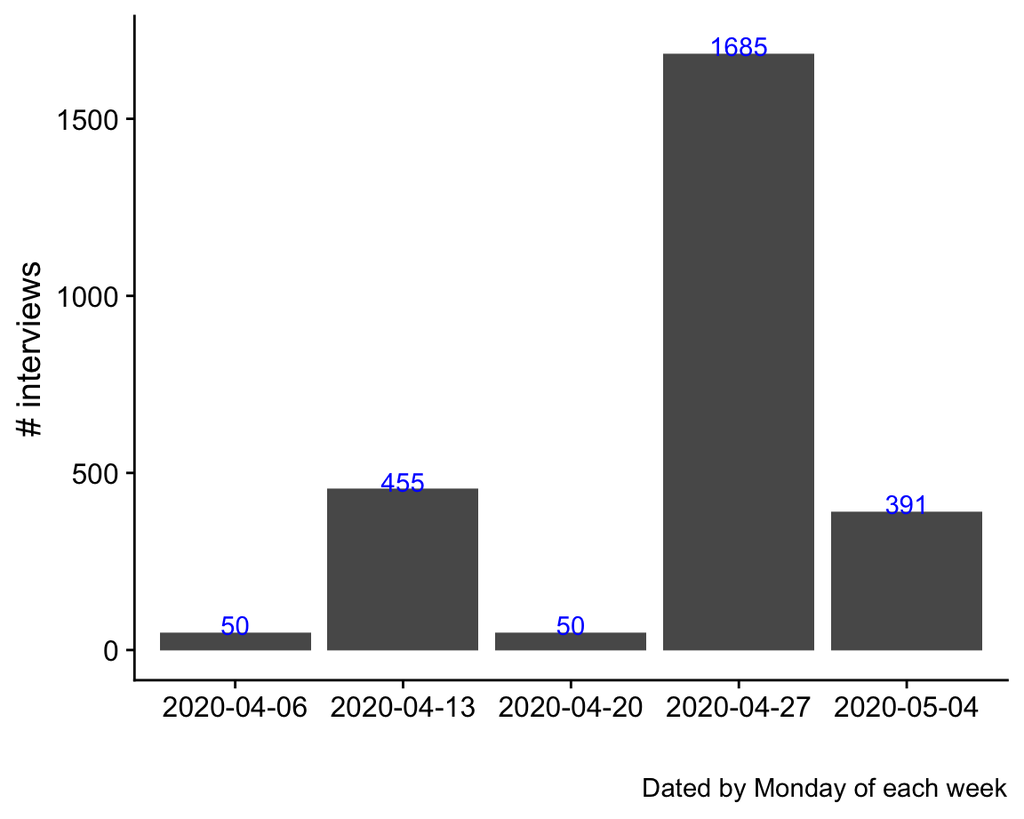

#### Age/sex

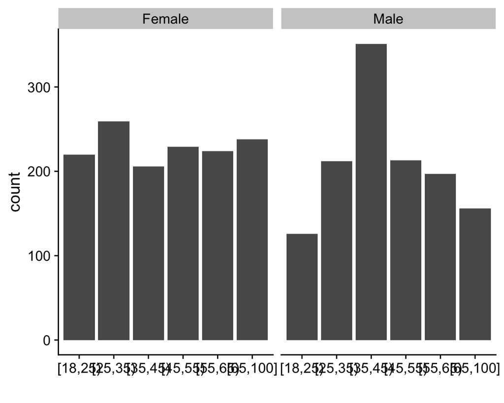

#### Race/ethnicity

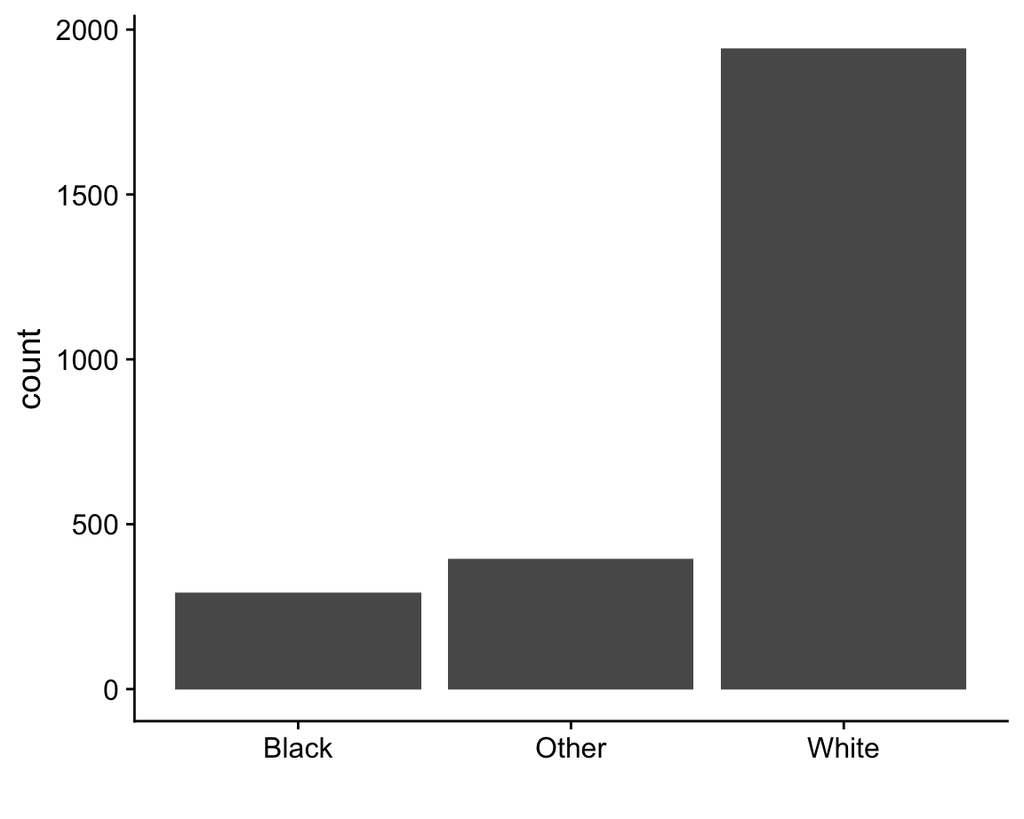

#### Household size

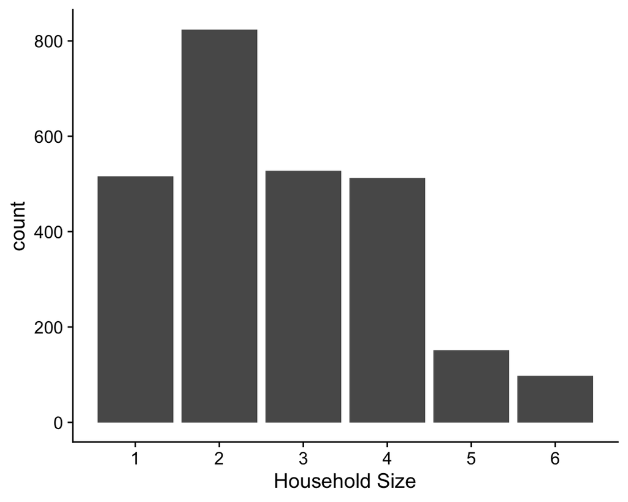

### Contact definition

We analyze two types of contacts: total contacts and non-household contacts.

We ask respondents to provide the age and gender of everyone in her household. We assume that a respondent had contact with everyone in her household; thus, total contacts is the sum of non-household contacts and household members.

For non-household contacts, respondents to the survey were told to consider someone a contact using this text:

> We would like to ask you some questions about people you had **in-person conversational contact** with yesterday.

> By **in-person conversational contact**, we mean a two-way conversation with three or more words in the physical presence of another person.

> You might have conversational contact with family members, friends, co-workers, store clerks, bus drivers, and so forth.

> (**Please do not count people you contacted exclusively by telephone, text, or online.** Only consider people you interacted with face-to-face.)

Using this definition, respondents were asked how many people who do not live in their households they had contact with on the day before the survey.

### Data

#### Microdata

We plan to make a version of the data with no identifying information publicly available as soon as we can. If you are a disease modeler who urgently needs to see the microdata, please reach out to us by email.

The estimated mixing matrices are reproduced as tables below. Note that these are the crude estimates, and have not had a symmetry constraint enforced.

#### Non-hh contact mixing estimates

| ego_age | alter_age | weighted_n | raw_n | num_interviews | weighted_num_interviews | ego_acs_N | alter_acs_N | unadj_avg_per_ego |
| --- | --- | --- | --- | --- | --- | --- | --- | --- |
| [18,25) | [0,18) | 103.495964 | 59 | 346 | 338.9917 | 30.64812 | NA | 0.3053053 |
| [18,25) | [18,25) | 504.163825 | 115 | 346 | 338.9917 | 30.64812 | 30.64812 | 1.4872452 |
| [18,25) | [25,35) | 199.184302 | 56 | 346 | 338.9917 | 30.64812 | 45.27702 | 0.5875787 |
| [18,25) | [35,45) | 128.714485 | 24 | 346 | 338.9917 | 30.64812 | 41.68729 | 0.3796980 |
| [18,25) | [45,55) | 67.630782 | 27 | 346 | 338.9917 | 30.64812 | 41.59234 | 0.1995057 |
| [18,25) | [55,65) | 5.811184 | 14 | 346 | 338.9917 | 30.64812 | 42.28218 | 0.0171426 |
| [18,25) | [65,100] | 138.593498 | 12 | 346 | 338.9917 | 30.64812 | 52.40755 | 0.4088404 |
| [25,35) | [0,18) | 108.686890 | 74 | 471 | 446.9116 | 45.27702 | NA | 0.2431955 |
| [25,35) | [18,25) | 76.862824 | 69 | 471 | 446.9116 | 45.27702 | 30.64812 | 0.1719866 |
| [25,35) | [25,35) | 459.441062 | 207 | 471 | 446.9116 | 45.27702 | 45.27702 | 1.0280356 |
| [25,35) | [35,45) | 122.354911 | 80 | 471 | 446.9116 | 45.27702 | 41.68729 | 0.2737788 |
| [25,35) | [45,55) | 71.957376 | 55 | 471 | 446.9116 | 45.27702 | 41.59234 | 0.1610103 |
| [25,35) | [55,65) | 55.147666 | 37 | 471 | 446.9116 | 45.27702 | 42.28218 | 0.1233973 |
| [25,35) | [65,100] | 26.977919 | 28 | 471 | 446.9116 | 45.27702 | 52.40755 | 0.0603652 |
| [35,45) | [0,18) | 160.757386 | 116 | 557 | 439.7286 | 41.68729 | NA | 0.3655832 |
| [35,45) | [18,25) | 110.860701 | 47 | 557 | 439.7286 | 41.68729 | 30.64812 | 0.2521116 |
| [35,45) | [25,35) | 264.457715 | 173 | 557 | 439.7286 | 41.68729 | 45.27702 | 0.6014112 |
| [35,45) | [35,45) | 578.402703 | 262 | 557 | 439.7286 | 41.68729 | 41.68729 | 1.3153629 |
| [35,45) | [45,55) | 59.527055 | 53 | 557 | 439.7286 | 41.68729 | 41.59234 | 0.1353723 |
| [35,45) | [55,65) | 78.751121 | 39 | 557 | 439.7286 | 41.68729 | 42.28218 | 0.1790903 |
| [35,45) | [65,100] | 24.931269 | 28 | 557 | 439.7286 | 41.68729 | 52.40755 | 0.0566969 |
| [45,55) | [0,18) | 119.733935 | 54 | 442 | 410.7716 | 41.59234 | NA | 0.2914854 |
| [45,55) | [18,25) | 28.478275 | 23 | 442 | 410.7716 | 41.59234 | 30.64812 | 0.0693287 |
| [45,55) | [25,35) | 112.330049 | 83 | 442 | 410.7716 | 41.59234 | 45.27702 | 0.2734611 |
| [45,55) | [35,45) | 173.477957 | 98 | 442 | 410.7716 | 41.59234 | 41.68729 | 0.4223222 |
| [45,55) | [45,55) | 233.006605 | 122 | 442 | 410.7716 | 41.59234 | 41.59234 | 0.5672412 |
| [45,55) | [55,65) | 69.539094 | 49 | 442 | 410.7716 | 41.59234 | 42.28218 | 0.1692889 |
| [45,55) | [65,100] | 62.286875 | 46 | 442 | 410.7716 | 41.59234 | 52.40755 | 0.1516338 |
| [55,65) | [0,18) | 60.399464 | 30 | 421 | 463.4103 | 42.28218 | NA | 0.1303369 |
| [55,65) | [18,25) | 37.201584 | 31 | 421 | 463.4103 | 42.28218 | 30.64812 | 0.0802779 |
| [55,65) | [25,35) | 204.945243 | 96 | 421 | 463.4103 | 42.28218 | 45.27702 | 0.4422544 |
| [55,65) | [35,45) | 212.242349 | 77 | 421 | 463.4103 | 42.28218 | 41.68729 | 0.4580009 |
| [55,65) | [45,55) | 250.749405 | 77 | 421 | 463.4103 | 42.28218 | 41.59234 | 0.5410959 |
| [55,65) | [55,65) | 100.761223 | 76 | 421 | 463.4103 | 42.28218 | 42.28218 | 0.2174342 |
| [55,65) | [65,100] | 101.909932 | 60 | 421 | 463.4103 | 42.28218 | 52.40755 | 0.2199130 |
| [65,100] | [0,18) | 26.165494 | 20 | 394 | 531.1861 | 52.40755 | NA | 0.0492586 |
| [65,100] | [18,25) | 23.641320 | 25 | 394 | 531.1861 | 52.40755 | 30.64812 | 0.0445067 |
| [65,100] | [25,35) | 96.356465 | 62 | 394 | 531.1861 | 52.40755 | 45.27702 | 0.1813987 |
| [65,100] | [35,45) | 147.293389 | 71 | 394 | 531.1861 | 52.40755 | 41.68729 | 0.2772915 |
| [65,100] | [45,55) | 180.725264 | 60 | 394 | 531.1861 | 52.40755 | 41.59234 | 0.3402296 |
| [65,100] | [55,65) | 71.803476 | 34 | 394 | 531.1861 | 52.40755 | 42.28218 | 0.1351757 |
| [65,100] | [65,100] | 240.920099 | 79 | 394 | 531.1861 | 52.40755 | 52.40755 | 0.4535512 |